# R0_Data_Week3

Data Structures: Breakout Groups

Brian Calhoon

5/18/2021

## Breakout Challenge

Create a data frame with 5 columns of data. One column should be binary, one column should be dates, one should be numeric, one should provide a grouping, and one is for you to decide.

Here’s an example, though any data frame that meets the criteria above is correct. Don’t forget to `set.seed()` so that others can reproduce your example.

```r
set.seed(47)
n = 9 #I chose 9 rows

df <- data.frame( team= rep(c("Cubs", "White Sox", "Brewers"), n/3)
                 , score = sample(3:9, n, replace = TRUE)
                 , date = c(rep(as.Date("2021-04-01"), 3), rep(as.Date("2021-04-02"), 3), rep(as.Date("2021-04-03"), 3))
                 , outcome = c("win", "loss", "loss", "loss", "win", "win", "win", "loss", "loss")
                 , attendance = sample(15000:50000, n))



df
```

```
##        team score       date outcome attendance
## 1      Cubs     5 2021-04-01     win      24096
## 2 White Sox     3 2021-04-01    loss      25629
## 3   Brewers     4 2021-04-01    loss      48163
## 4      Cubs     9 2021-04-02    loss      41247
## 5 White Sox     6 2021-04-02     win      19676
## 6   Brewers     3 2021-04-02     win      26674
## 7      Cubs     4 2021-04-03     win      48803
## 8 White Sox     7 2021-04-03    loss      17212
## 9   Brewers     9 2021-04-03    loss      45650
```

Now, we’ve got our dataset. Make a chart that includes multiple geometries such as `geom_point()`. `geom_line()`, or `geom_bar()`.

This first chart example is not very good. It’s an example of a chart that is not very useful. However, it does use the `ggrepel` library which is a good tool to understand because it helps move data labels out of the way of data in a chart.

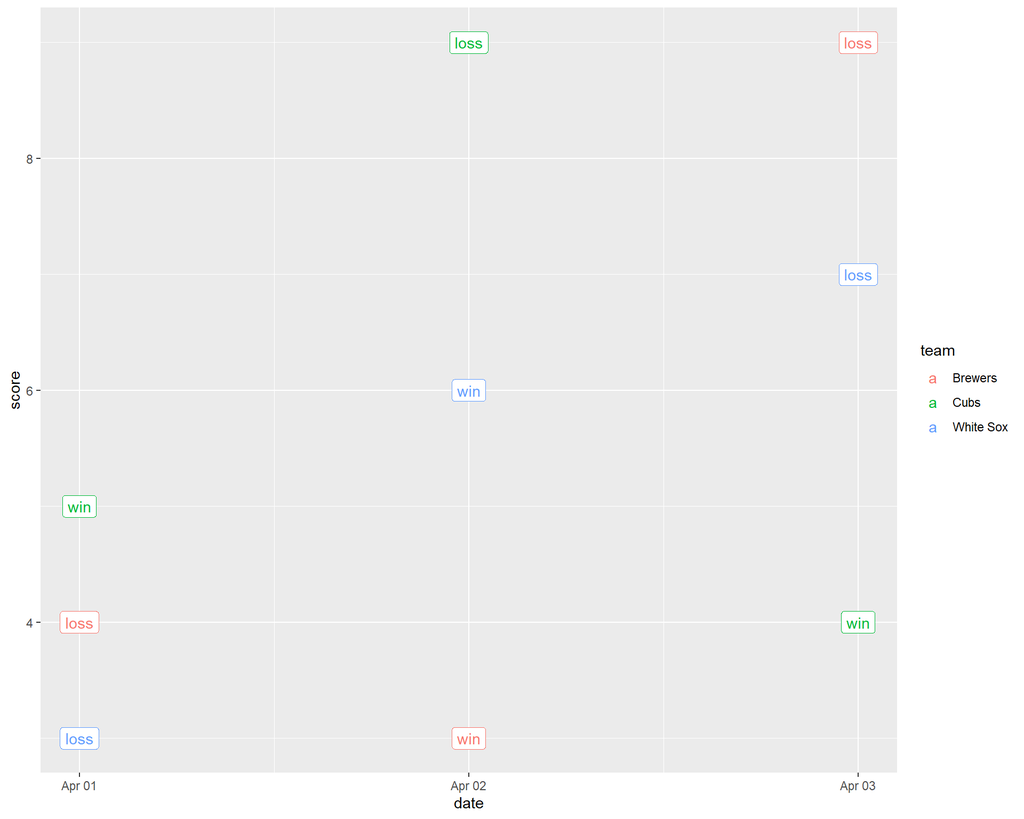

```r
ggplot(df
       , aes(x = date, y = score, color = team)) +
  geom_point() +
  geom_label(aes(label = outcome))
```

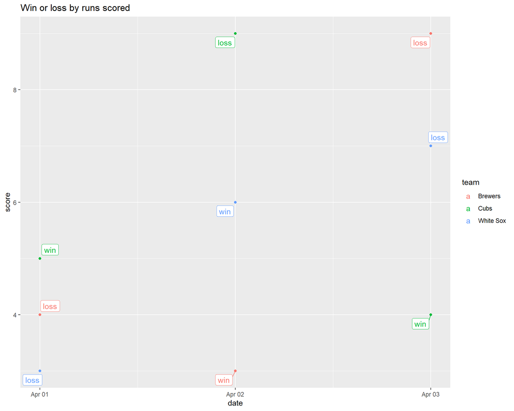

```r
#Oops, the labels are in the way. Let's move the labels

library(ggrepel) #this library shifts labels away from points on charts

plot <- ggplot(df
       , aes(x = date, y = score, color = team)) +
  geom_point() +
  geom_label_repel(aes(label = outcome)) #geom_label_repel is from the ggrepel library

plot +
  ggtitle("Win or loss by runs scored")
```

I didn’t like that first attempt. So, I’m going to manipulate the data to provide a better example.

```r
df1 <- df %>%
  group_by(team, outcome) %>%
  summarize(sum_score = sum(score))

df1
```

```
## # A tibble: 6 x 3
## # Groups:   team [3]
##   team      outcome sum_score
##   <chr>     <chr>       <int>
## 1 Brewers   loss           13
## 2 Brewers   win             3
## 3 Cubs      loss            9
## 4 Cubs      win             9
## 5 White Sox loss           10
## 6 White Sox win             6
```

So, the White Sox and the Brewers scored more runs in their losses than their wins, and the Cubs scored the same amount of runs.

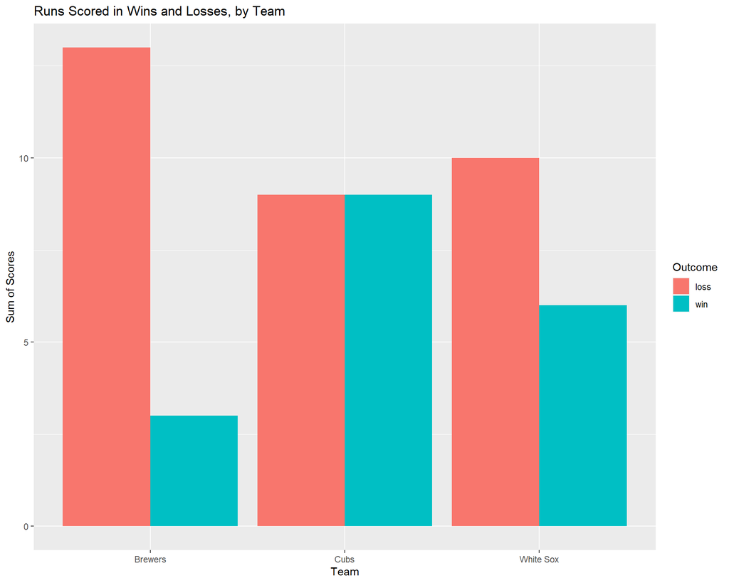

```r
#This makes a basic plot that shows the sums of scores in wins/losses
plot1 <- ggplot(df1, aes(x = team, y = sum_score, fill = outcome)) +
  geom_bar(position="dodge", stat = "identity") +
  labs(title = "Runs Scored in Wins and Losses, by Team"
       , fill = "Outcome"
       , x = "Team"
       , y = "Sum of Scores")

plot1
```

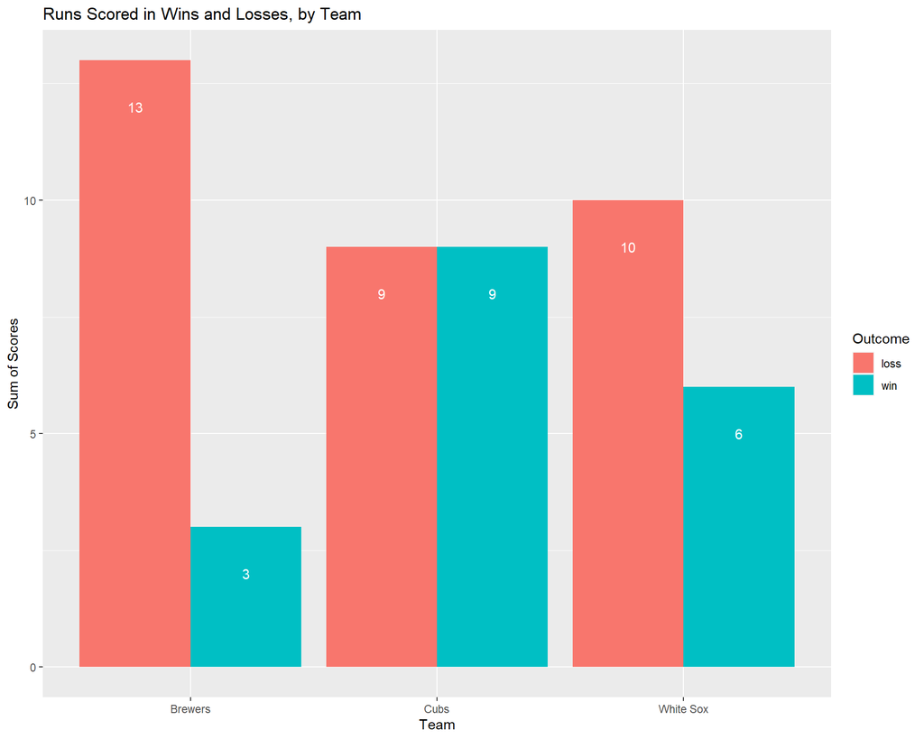

```r
#Now add some labels to the bars

plot2 <- plot1 +
  geom_text(aes(label = sum_score
                , y = sum_score -1)
            , position = position_dodge(.9)
            , color = "white")

plot2
```

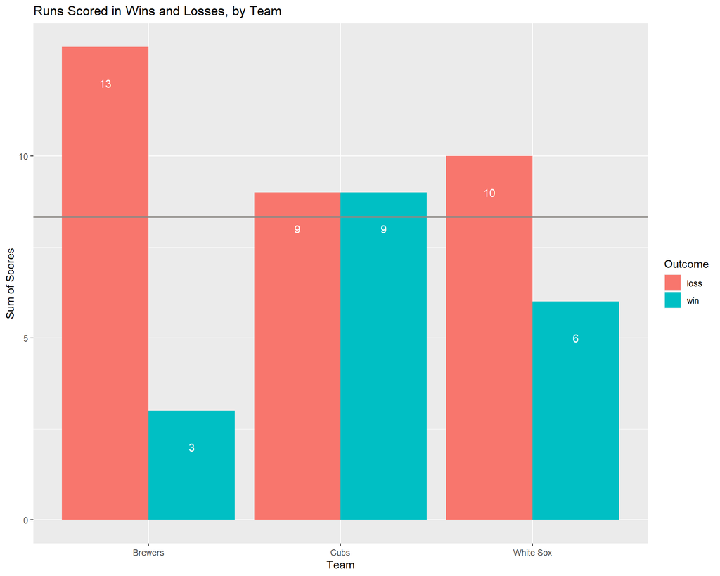

```r
#Now add a horizontal line to show the average score of all games

plot3 <- plot2 +
  geom_hline(yintercept = mean(df1$sum_score)
             , color = "#8C8985"
             , size = 1)

plot3
```

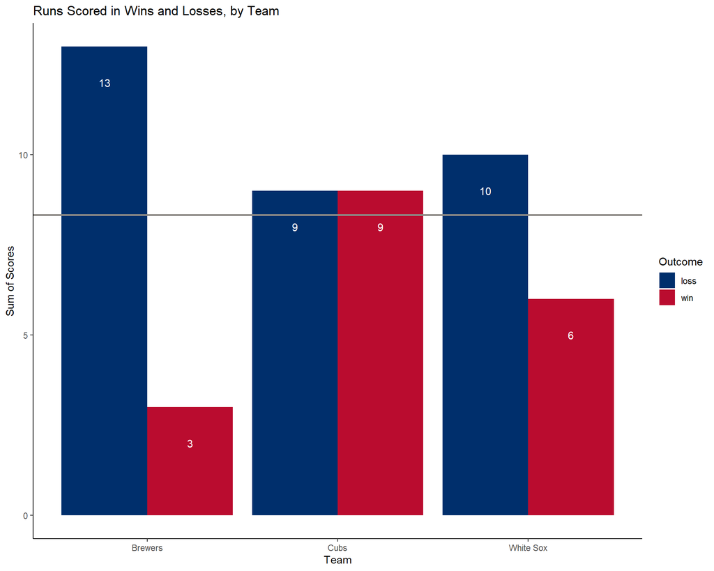

```r
#Now, let's add USAID colors and a theme

plot3 +
  scale_fill_manual(values = c("#002F6C", "#BA0C2F")) +
  theme_classic()
```